# Final Project

Liz Austin, Casey Gibson, and Zhengfan Wang

November 15, 2017

# Lyme Disease CDC Data

Data source: https://www.cdc.gov/lyme_project_project/stats/index.html

Clustering by region reference: https://www2.census.gov/geo/pdfs/maps-data/maps/reference/us_regdiv.pdf

### Casey

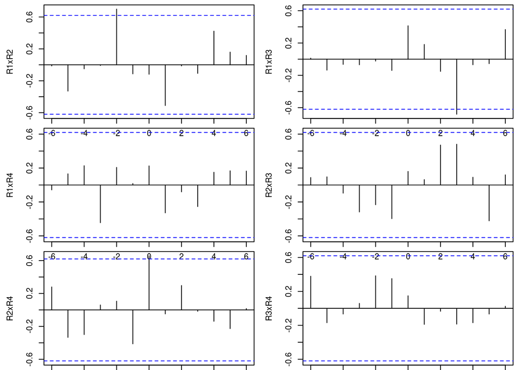

# Dataset sample

```r
lyme[1:10,]
```

```
##          State X2006 X2007 X2008 X2009 X2010 X2011 X2012 X2013 X2014 X2015
## 1      Alabama    11    13     6     3     1     9    13    11    28    14
## 2       Alaska     3    10     6     7     7     9     4    14     5     1
## 3      Arizona    10     2     2     3     2     8     7    22    14     8
## 4     Arkansas     0     1     0     0     0     0     0     0     0     0
## 5   California    85    75    74   117   126    79    61    90    54    83
## 6     Colorado     0     0     2     0     1     0     0     0     0     0
## 7  Connecticut  1788  3058  2738  2751  1964  2004  1653  2111  1719  1873
## 8     Delaware   482   715   772   984   656   767   507   400   341   334
## 9      Florida    34    30    72    77    56    78    67    87    85   116
## 10     Georgia     8    11    35    40    10    32    31     8     4     8
##    Region
## 1       3
## 2       4
## 3       4
## 4       3
## 5       4
## 6       4
## 7       1
## 8       3
## 9       3
## 10      3
```

```r
lyme[51:60,]
```

```
##      State X2006 X2007 X2008 X2009 X2010 X2011 X2012 X2013 X2014 X2015
## NA    <NA>    NA    NA    NA    NA    NA    NA    NA    NA    NA    NA
## NA.1  <NA>    NA    NA    NA    NA    NA    NA    NA    NA    NA    NA
## NA.2  <NA>    NA    NA    NA    NA    NA    NA    NA    NA    NA    NA
## NA.3  <NA>    NA    NA    NA    NA    NA    NA    NA    NA    NA    NA
## NA.4  <NA>    NA    NA    NA    NA    NA    NA    NA    NA    NA    NA
## NA.5  <NA>    NA    NA    NA    NA    NA    NA    NA    NA    NA    NA
## NA.6  <NA>    NA    NA    NA    NA    NA    NA    NA    NA    NA    NA
## NA.7  <NA>    NA    NA    NA    NA    NA    NA    NA    NA    NA    NA
## NA.8  <NA>    NA    NA    NA    NA    NA    NA    NA    NA    NA    NA
## NA.9  <NA>    NA    NA    NA    NA    NA    NA    NA    NA    NA    NA
##      Region
## NA     <NA>
## NA.1   <NA>
## NA.2   <NA>
## NA.3   <NA>
## NA.4   <NA>
## NA.5   <NA>
## NA.6   <NA>
## NA.7   <NA>
## NA.8   <NA>
## NA.9   <NA>
```

## Casey’s part

#### TODO

##### Model Fits

- Locally level model (DONE)
- AR model (DONE)
- Seasonal model (DONE)
- Temperature covariate model (DONE)
- Hierarchical model (DONE)
- Multiple covariate model
- Simple SIR model #####Model CV
- Compare residuals/ACF
- Investigate techniques for statistical inference on time varying regression coefficients

## Introduction

In order to examine the time-varying effects of Lyme disease incidence across the country we will employ the state space model framework. This will allow us to model both the underlying incidence of Lyme over time while accounting for correlation between observations. We first present a breif overview of state-space models and the types of inferences that can be made.

## Background

State space models are defined in terms of a given time-series of observations $Y_1,Y_2,...,Y_n$ and a set of latent factors $Z_1,Z_2,....Z_n$.

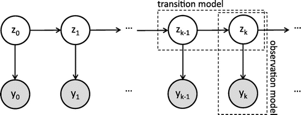

This setup allows us to decompose a joint likleihood as follows.

$$L(z_1,z_2,...z_n | y_1,y_2,...,y_n) = p(z_1)\prod_{i=2}^n p(z_i |z_{i-1})p(y_i |z_i)$$

We can see that this decomposes into a series of product terms containing an observation model, a density describing the probability of an observation given a state, and a transition model, a density describing the probability of moving from one state to the next. In addition, all states obey the Markov property, meaning they are conditionally independent of all other states given the previous one.

This set-up lends itself nicely to particle filtering, which we will treat as a black-box inference algorithm to get at the likelihood above.

One further extension is to consider top-level unknown parameters. We can write the likelihood given a parameter vector $\theta$ as
$$L(z_1,z_2,...z_n | y_1,y_2,...,y_n, \theta) = p(z_1 | \theta)\prod_{i=2}^n p(z_i |z_{i-1}, \theta)p(y_i |z_i, \theta)p(\theta)$$

To begin with, lets restrict our analysis to Massachusetts’ data.

### Locally Level

A simple locally level model takes the form,
$$Z_t \sim N(Z_{t-1},\sigma^2)$$

$$Y_t \sim Pois(exp(X_t))$$
where we take our observation model to be $Poisson$ to restrict it to the integers.

This model is called “locally level” because we can think of it as an intercept only regression model where each $Y_i$ is assigned an intercept $Z_i$ and these intercepts follow a Gaussian random walk.

```
## * Parsing model in: /home/gcgibson/Desktop/lyme_project/pois.bug
##   Declaring variables
##   Graph size: 39
```

```
## * Initializing PMMH
```

```
## * Adapting PMMH with 50 particles
##   |++++++++++++++++++++++++++++++++++++++++++++++++++| 500 iterations in 18.80 s
```

```
## * Generating 200 PMMH samples with 50 particles
##   |**************************************************| 1000 iterations in 28.65 s
```

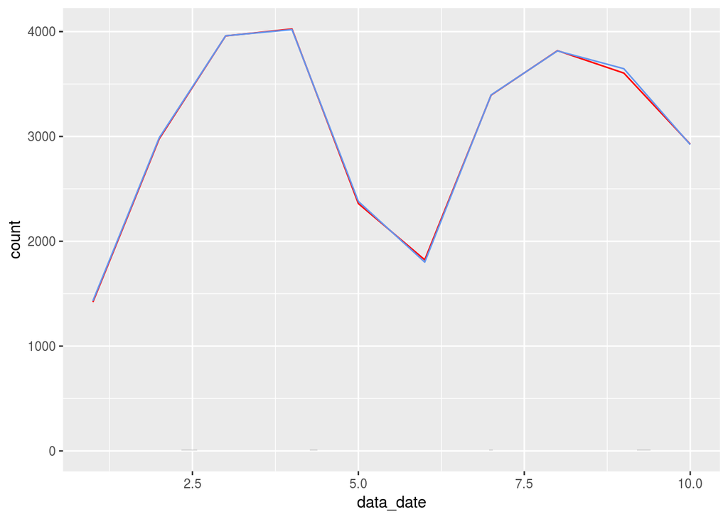

```
## [1] "Estimted log variance"
```

```
## mcmcarray:
## $mean
## [1] -0.7718157
##
## $probs
## [1] 0.025 0.975
##
## $quant
## $quant$`0.025`
## [1] -1.198063
##
## $quant$`0.975`
## [1] -0.2419523
##
##
## Marginalizing over: iteration(200)
```

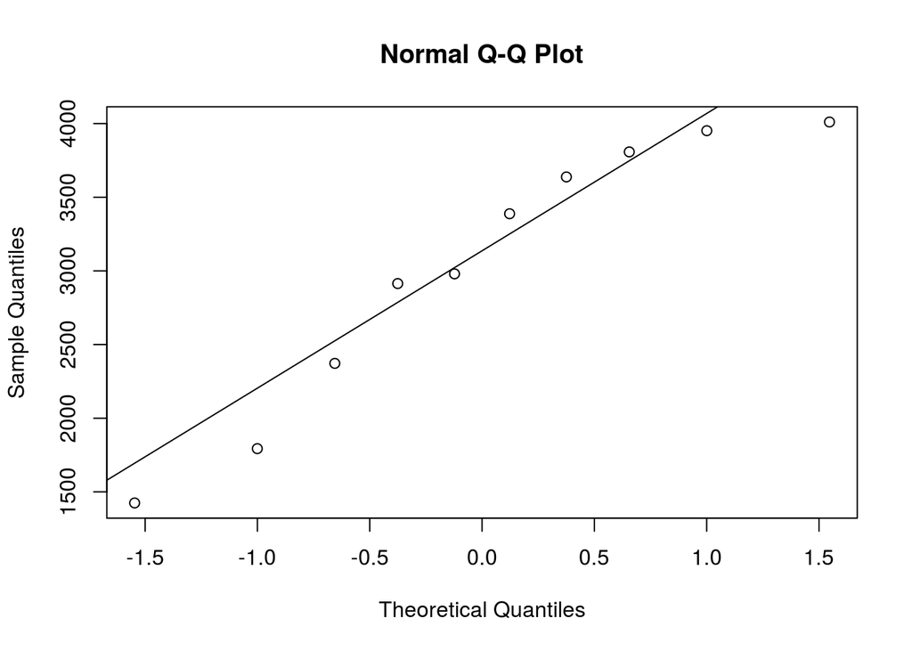

We can see that locally-level model is able to almost perfectly capture the data. This is unsurprising because we have imposed no constraints on the state space. Although this model is a good baseline, it offers little in terms of inference or predicatbility. In the absence of any additional information, the model predicts that the true underlying incidence is simply the observed incidence. In addition, point predictions will take the following form:
$$E(Z_{t+1} | Z_t) = z_t$$
$$E(Y_t |Z_t) = exp(z_t)$$
so predictions for all $h$ steps ahead will remain at a constant value, $exp(z_t)$.

### Seasonal

We next impose our knowledge of the seasonal effects of lyme disease onto the state-space model by incorporating the following trasformation

$$\begin{bmatrix}Z_{t,1} \\ Z_{t,2} \end{bmatrix} \sim N(\begin{bmatrix} cos(2\pi/4) & sin(2\pi/4) \\ -sin(2\pi/4) &cos(2\pi/4) \end{bmatrix} \begin{bmatrix}Z_{t-1,1} \\ Z_{t-1,2} \end{bmatrix} ,\begin{bmatrix} \sigma^2 \\0 \end{bmatrix})$$

```
## * Parsing model in: /home/gcgibson/Desktop/lyme_project/seasonal_pois.bug
```

```
##   Declaring variables
##   Graph size: 54
```

```
## * Assigning node samplers
## * Running SMC forward sampler with 100000 particles
##   |**************************************************| 10 iterations in 58.99 s
```

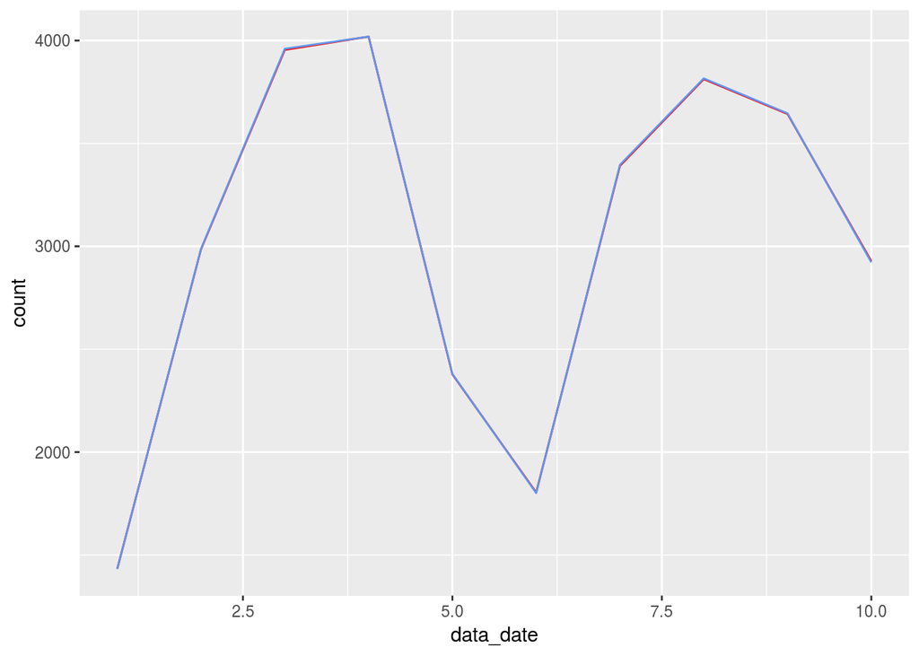

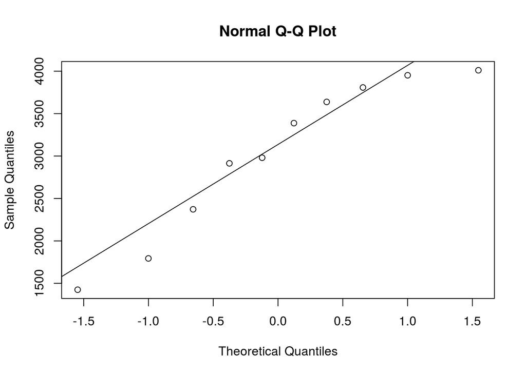

Although both models fit the data very well, this model is able to capture the cyclic components perfectly and also is able to generate cyclic predictions since

$$E(X_{t} |X_{t-1}) = Gx_{t-1}$$
$$E(Y_t | X_{t,1}) = exp(cos(2\pi)x_{t,1} + sin(2\pi)x_{t,2})$$

### Model Comparison

In order to evaluate model fit we can compare the difference in the log-likelihoods of each model. We cannot, however, perform any hypothesis testing because the degrees of freedom are undefined (since every $Y_t$ is assigned a $Z_t$, the df is technically $0$ for all models).
$$D = -2(ln(L(D | M_1)) - ln(L(D |M_2))$$

```
## [1] 87.27224
```

### Auto-regressive model

We can further extend the interpritability of our latent states by incorporating an auto-regressive term. The AR-SSM take sthe following form

$$X_t \sim N(\phi_1X_{t-1} +\phi_2 X_{t-2},\sigma^2)$$

$$Y_t \sim Pois(exp(X_t))$$
We can perform top level inference on the parameters $\phi_1,\phi_2$ using PMMH (Particle Marginal Metropolis Hastings), which allows us to subsitutite a particle filter likelihood into the regular MH algorithm given a draw from a proposal distribution over $\phi_1$ and $\phi_2$

```
## * Parsing model in: /home/gcgibson/Desktop/lyme_project/ar_dlm.bug
```

```
##   Declaring variables
##   Graph size: 62
```

```
## * Assigning node samplers
## * Running SMC forward sampler with 100000 particles
##   |**************************************************| 10 iterations in 56.63 s
```

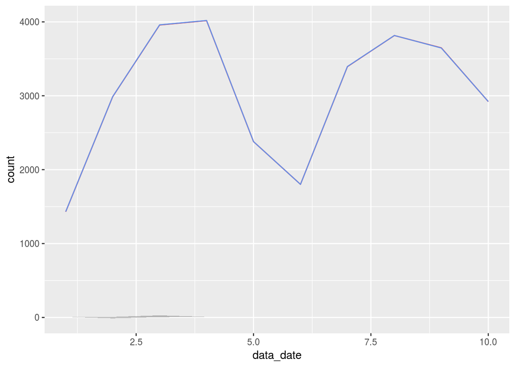

### Model comparison

Although we cannot do strict hypothesis testing using the deviance, we can still compare deviances to get a sense of model preformance.

```
## [1] 87.27224
```

```
## [1] 25.07425
```

We can see that the $AR(2)$ model seems to fit the model better, however, we cannot conclude this in a hypothesis testing framework.

### Dynamic Regression

In order to incorporate additional sources of information, we next consider the case where we have an observed series of temperature over the duration of lyme disease incidence.

This model takes the form

$$\beta_t \sim N(\beta_{t-1},\sigma^2)$$

$$Y_t \sim Pois(Temp_t*exp(\beta_t))$$

In other words, we can now interpet the $Z's$ as time varying regression coefficients that have a multiplicitaive effect of $exp(\beta_t)$ on the temperature.

In order to evaluate this model, we first generate random temperature draws.

```
## * Parsing model in: /home/gcgibson/Desktop/lyme_project/pois_with_temp.bug
##   Declaring variables
##   Graph size: 61
```

```
## * Initializing PMMH
```

```
## * Adapting PMMH with 50 particles
##   |++++++++++++++++++++++++++++++++++++++++++++++++++| 500 iterations in 13.93 s
```

```
## * Generating 200 PMMH samples with 50 particles
##   |**************************************************| 1000 iterations in 28.29 s
```

We can now examine the fit of the temperature model.

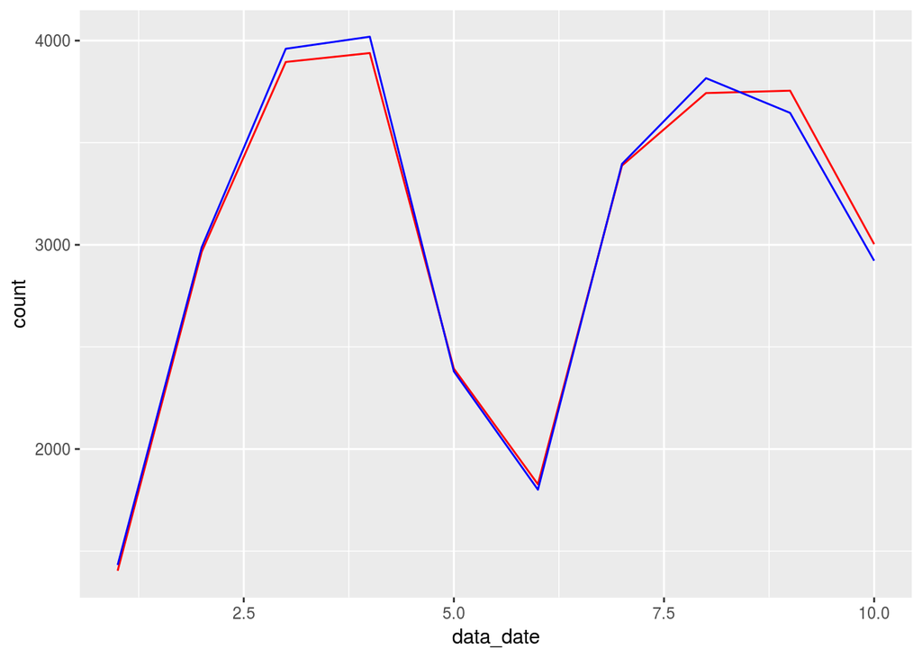

We can see that in the presence of temperature the fit remains good. However, if we investigate the latent state of lyme, we can now interpret the $\theta_t$’s as dynamic regression coefficients.

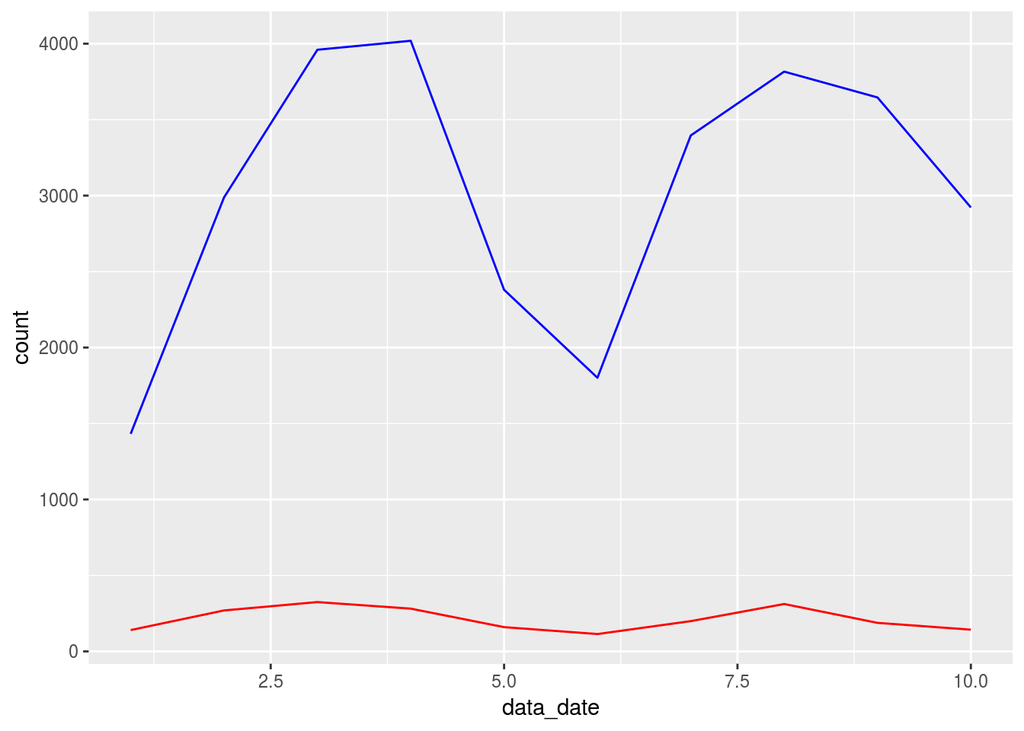

### Hierarchical

In order to leverage the hierarchical nature of the data we consider an extension to hierarchical dynamic models taking the form

$$Z_t \sim N(Z_{t-1},\sigma^2)$$
$$X_{tj} \sim N(Z_t,1)$$
$$Y_{tj} \sim Pois(exp(X_{tj}))$$

where $j$ indexes region $j = [1,2,3,4]$.

The intution here is that there is some true country wide lyme incidence, and regional variational around this country level.

```
## * Parsing model in: /home/gcgibson/Desktop/lyme_project/hierarchical.bug
##   Declaring variables
##   Graph size: 155
```

```
## * Initializing PMMH
```

```
## * Adapting PMMH with 10 particles
##   |++++++++++++++++++++++++++++++++++++++++++++++++++| 500 iterations in 24.42 s
```

```
## * Generating 200 PMMH samples with 10 particles
##   |**************************************************| 1000 iterations in 48.61 s
```

```
## [1] "Global log precision "
```

```
## [1] 1.319695
```

```
## [1] 1.464602
```

```
## [1] 1.475287
```

```
## [1] 1.374284
```

```
## [1] 1.359185
```